# ANOVA 1/2: Analyses of Variance in Mask-Related Sentiment Across Weeks, based on All Tweets of Coronavirus-Data-Masks Index

Rachael White // Health Analytics Challenge Lab 2020

August 11, 2020

## Overview

### The following is the first in a two-part, one-way ANOVA analysis aiming to answer the following questions about the sentiment scores of tweets in our coronavirus-data-masks index:

#### 1. Does mean mask-related tweet sentiment differ significantly across weeks, over the tweet collection time range (3/16/2020-8/1/2020)?

- Null hypothesis: mean1 = mean2 = mean3 … meanN

#### 2. Does mean mask-related tweet sentiment differ significantly among states, over the same time range? (To be conducted separately)

- Null hypothesis: mean1 = mean2 = mean3 … meanN

### Search configuration

```r
# query start date/time (inclusive)
rangestart <- "2020-01-01 00:00:00"

# query end date/time (exclusive)
rangeend <- "2020-08-01 00:00:00"

# text filter restricts results to only those containing words, phrases, or meeting a boolean condition. This query syntax is very flexible and supports a wide variety of filter scenarios:
# words: text_filter <- "cdc nih who"  ...contains "cdc" or "nih" or "who"
# phrase: text_filter <- '"vitamin c"' ...contains exact phrase "vitamin c"
# boolean condition: <- '(cdc nih who) +"vitamin c"' ...contains ("cdc" or "nih" or "who") and exact phrase "vitamin c"
#full specification here: https://www.elastic.co/guide/en/elasticsearch/reference/current/query-dsl-simple-query-string-query.html
text_filter <- ""

# location filter acts like text filter except applied to the location of the tweet instead of its text body.
location_filter <- ""

# if FALSE, location filter considers both user-povided and geotagged locations. If TRUE, only geotagged locations are considered.
must_have_geo <- FALSE

# query semantic similarity phrase
semantic_phrase <- ""

# return results in chronological order or as a random sample within the range
# (ignored if semantic_phrase is not blank)
random_sample <- TRUE
# if using random sampling, optionally specify a seed for reproducibility. For no seed, set to NA.
random_seed <- NA
# number of results to return (to return all results, set to NA)
resultsize <- NA
# minimum number of results to return. This should be set according to the needs of the analysis (i.e. enough samples for statistical significance)
min_results <- 1
```

## Results

| results.tweet.count |
| --- |
| 1013038 |

```
## # A tibble: 1,013,038 x 4
##    sentiment  week date       datetime
##        <dbl> <dbl> <date>     <dttm>
##  1   -0.958     29 2020-07-12 2020-07-12 03:33:01
##  2    0.0772    28 2020-07-06 2020-07-06 23:22:02
##  3    0         24 2020-06-12 2020-06-12 21:43:42
##  4    0.727     27 2020-07-02 2020-07-02 19:17:20
##  5    0.081     14 2020-04-01 2020-04-01 08:15:05
##  6   -0.555     20 2020-05-10 2020-05-10 22:31:43
##  7    0.05      26 2020-06-25 2020-06-25 16:26:00
##  8    0.670     26 2020-06-23 2020-06-23 11:16:01
##  9   -0.296     31 2020-07-27 2020-07-27 13:59:55
## 10   -0.916     30 2020-07-22 2020-07-22 00:48:59
## # … with 1,013,028 more rows
```

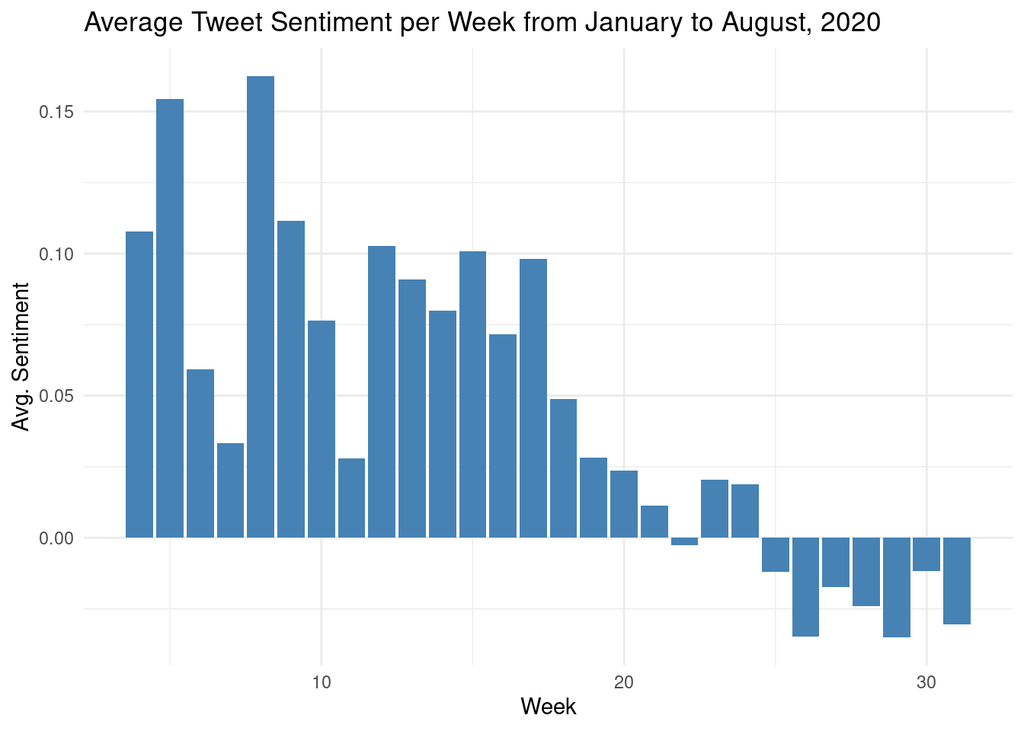

Average sentiment as represented in these tweets can be observed to decrease over the timeline of the pandemic.

## Data Cleaning/Organizing

We inspect the counts of tweets posted during each week, ordered least to greatest, to make sure all weeks are sufficiently represented:

```
## # A tibble: 28 x 2
##     week count
##    <dbl> <int>
##  1     4    15
##  2     8    16
##  3     7    21
##  4     6    23
##  5     5    61
##  6     9    87
##  7    10   142
##  8    11   231
##  9    12  7663
## 10    13 17760
## # … with 18 more rows
```

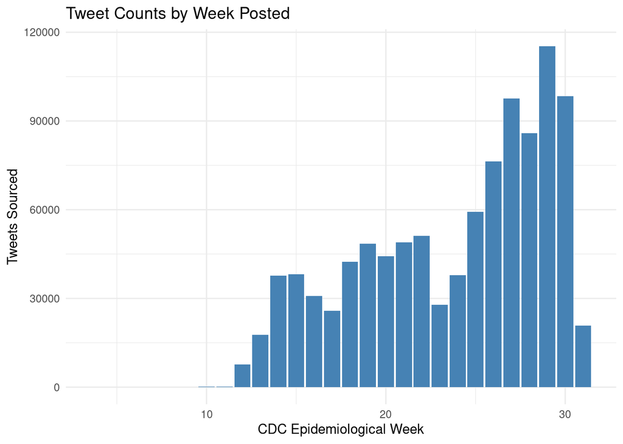

```
## # A tibble: 1,012,442 x 4
##    sentiment  week date       datetime
##        <dbl> <dbl> <date>     <dttm>
##  1   -0.958     29 2020-07-12 2020-07-12 03:33:01
##  2    0.0772    28 2020-07-06 2020-07-06 23:22:02
##  3    0         24 2020-06-12 2020-06-12 21:43:42
##  4    0.727     27 2020-07-02 2020-07-02 19:17:20
##  5    0.081     14 2020-04-01 2020-04-01 08:15:05
##  6   -0.555     20 2020-05-10 2020-05-10 22:31:43
##  7    0.05      26 2020-06-25 2020-06-25 16:26:00
##  8    0.670     26 2020-06-23 2020-06-23 11:16:01
##  9   -0.296     31 2020-07-27 2020-07-27 13:59:55
## 10   -0.916     30 2020-07-22 2020-07-22 00:48:59
## # … with 1,012,432 more rows
```

## Analysis

We now check that our data holds up against the assumptions of running an ANOVA. The key assumptions are:

1. No major outliers
2. Normality of residuals
3. Homoscedascicity

We first check for outliers using boxplots for each week, and remove any if found.

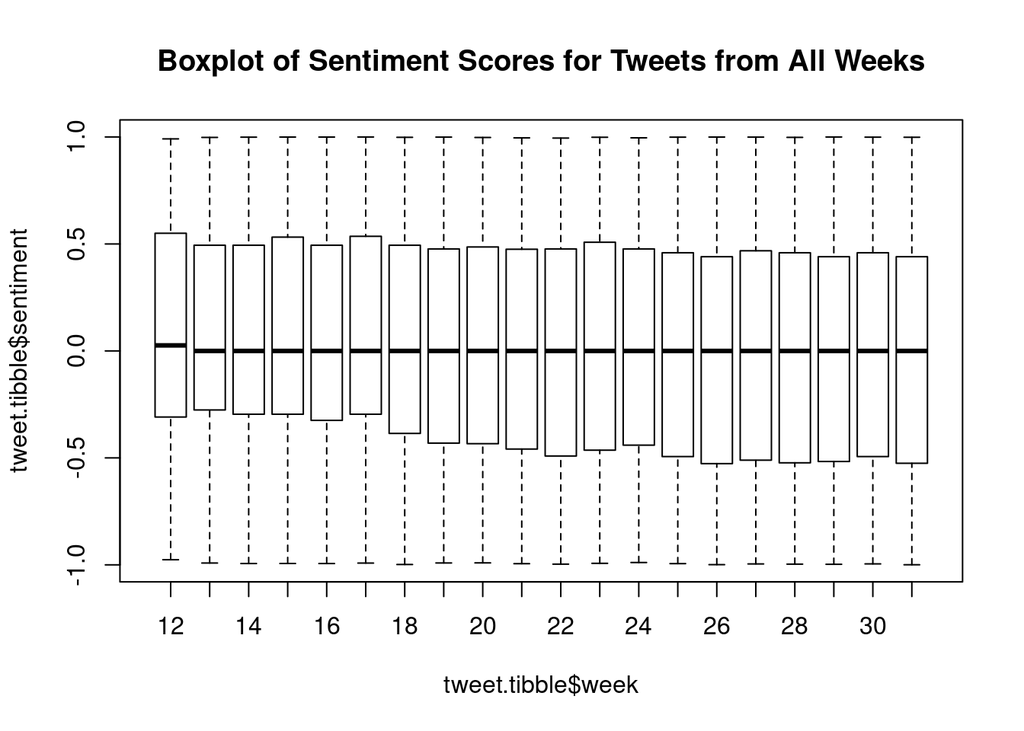

No apparent sentiment outliers across weeks, so assumption 1 is met. For convenience, we proceed with the ANOVA, then use the results to circle back and check the other two key assumptions of this test.

```r
aov_results <- aov(tweet.tibble$sentiment~week, data=tweet.tibble);
#
# #Output summarized results of ANOVA
summary(aov_results)
```

```
##                  Df Sum Sq Mean Sq F value Pr(>F)
## week             19   1762   92.72   317.3 <2e-16 ***
## Residuals   1012422 295887    0.29
## ---
## Signif. codes:  0 '***' 0.001 '**' 0.01 '*' 0.05 '.' 0.1 ' ' 1
```

Based on this highly significant result (p < 2e-16), we have reason to believe that the weekly sentiment average for at least one week differs significantly from the rest. We check our remaining two assumptions for running the ANOVA for posterity, to get an idea of how confident we can be in this finding.

Starting from #2, we assess the normality of residuals from our ANOVA results.

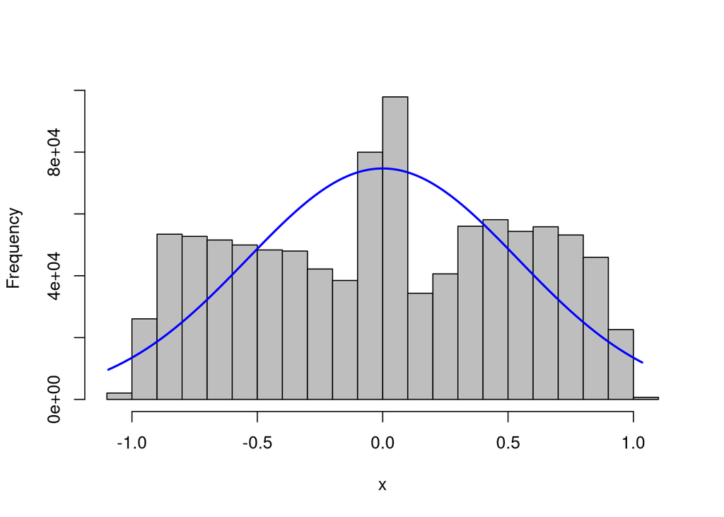

```r
#CHECK ASSUMPTIONS

#1. Normality of Residuals
Residuals = resid(aov_results)

###### Visual Check Normality of Residuals
plotNormalHistogram(Residuals)
```

Next, we check homoscedascicity with a non-constant error variance test.

```
##
##  studentized Breusch-Pagan test
##
## data:  LM_weekly_sentiment
## BP = 3873.2, df = 19, p-value < 2.2e-16
```

The Breusch-Pagan test indicates that heteroscedasticity is present, so unfortunately, that assumption of ANOVA is violated.

We normally would not proceed further with the analysis of beween-group differences given the instability of the ANOVA outcome itself, but in this case, we’ll still investigate which weeks exactly were unusual. We’ll use the standard Bonferroni’s test to look at between-group differences; with this correction, significance level is adjusted for the quantity of comparisons being made.

```
##
##  Pairwise comparisons using t tests with pooled SD
##
## data:  tweet.tibble$sentiment and tweet.tibble$week
##
##    12      13      14      15      16      17      18      19      20
## 13 1.00000 -       -       -       -       -       -       -       -
## 14 0.14786 1.00000 -       -       -       -       -       -       -
## 15 1.00000 1.00000 1.7e-05 -       -       -       -       -       -
## 16 0.00141 0.02980 1.00000 3.7e-10 -       -       -       -       -
## 17 1.00000 1.00000 0.00477 1.00000 1.1e-06 -       -       -       -
## 18 2.2e-13 5.8e-16 1.1e-13 < 2e-16 3.1e-06 < 2e-16 -       -       -
## 19 < 2e-16 < 2e-16 < 2e-16 < 2e-16 < 2e-16 < 2e-16 2.3e-06 -       -
## 20 < 2e-16 < 2e-16 < 2e-16 < 2e-16 < 2e-16 < 2e-16 1.8e-09 1.00000 -
## 21 < 2e-16 < 2e-16 < 2e-16 < 2e-16 < 2e-16 < 2e-16 < 2e-16 0.00020 0.09356
```

[output cut: 52 more lines]

On inspection, it’s difficult to draw conclusions about which weeks notably differ, based on the sheer quantity of pairwise differences in the data. We’ll now re-factor the ANOVA to look at differences across months, to see if this paints a clearer picture of how mask-related sentiment has changed through time.

```
## # A tibble: 5 x 2
##   month mean_sentiment
##   <dbl>          <dbl>
## 1     3         0.0882
## 2     4         0.0796
## 3     5         0.0178
## 4     6        -0.0146
## 5     7        -0.0220
```

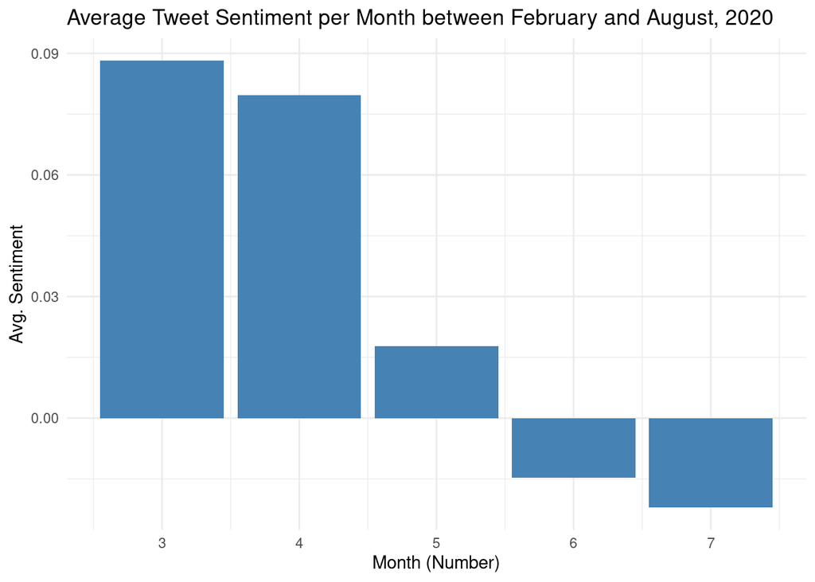

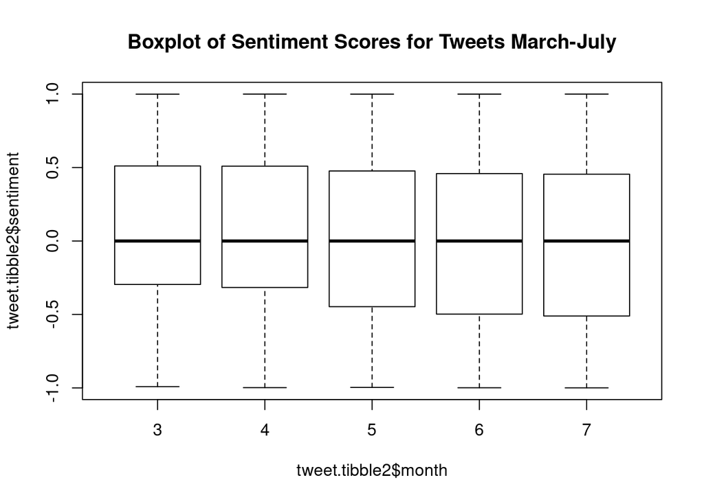

We find no apparent sentiment outliers across months, so ANOVA assumption 1 is met. We continue with the same procedure as previously done for sentiment-by-week.

```
##                  Df Sum Sq Mean Sq F value Pr(>F)
## month             4   1498   374.5    1280 <2e-16 ***
## Residuals   1012437 296151     0.3
## ---
## Signif. codes:  0 '***' 0.001 '**' 0.01 '*' 0.05 '.' 0.1 ' ' 1
```

The ANOVA result suggests that a significant difference exists, this time among the 5 months. We again perform the Bonferroni-corrected pairwise t-test to identify which months are significantly different from the rest:

```
##
##  Pairwise comparisons using t tests with pooled SD
##
## data:  tweet.tibble2$sentiment and tweet.tibble2$month
##
##   3       4       5       6
## 4 0.059   -       -       -
## 5 < 2e-16 < 2e-16 -       -
## 6 < 2e-16 < 2e-16 < 2e-16 -
## 7 < 2e-16 < 2e-16 < 2e-16 1.7e-06
##
## P value adjustment method: bonferroni
```

Based on the output, we find that mean sentiment scores for the month of March vs April differed with a borderline significant p of 0.059, that mean sentiment scores for May differed from March with a highly significant p of less than 2e-16, and so on. These results indicate overall that statistically significant differences in mean sentiment exist across, essentially, all months studied.

In the hopes of casting more light on this finding, we can follow up with a Dunnet’s Correction test, which will compare the mean sentiment for each month to a control mean. We choose the average sentiment from March, the earliest period in the pandemic’s development for which we have substantial Twitter data, as a baseline.

```
##
##   Simultaneous Tests for General Linear Hypotheses
##
## Multiple Comparisons of Means: Dunnett Contrasts
##
##
## Fit: aov(formula = sentiment ~ month, data = tweet.tibble2)
##
## Linear Hypotheses:
##             Estimate Std. Error t value Pr(>|t|)
## 4 - 3 == 0 -0.008583   0.003118  -2.752   0.0143 *
## 5 - 3 == 0 -0.070406   0.003031 -23.225   <0.001 ***
## 6 - 3 == 0 -0.102836   0.003003 -34.246   <0.001 ***
## 7 - 3 == 0 -0.110246   0.002926 -37.673   <0.001 ***
## ---
## Signif. codes:  0 '***' 0.001 '**' 0.01 '*' 0.05 '.' 0.1 ' ' 1
## (Adjusted p values reported -- single-step method)
```

This output is interpreted as follows:

- The difference in mean sentiment between month 4 (April) and month 3 (March) is significant at a significance level of .05; this difference has a p-value of 0.0143.
- The difference in mean sentiment between month 5 (May) and month 3 (March) is *highly* significant at a significance level of .05; this difference has a p-value of <0.001.
- The latter conclusion also applies to the average sentiments found for months 6 and 7 (June and July), both of which differ in a highly significant fashion from the average sentiment found for March.

```
##
##   Simultaneous Tests for General Linear Hypotheses
##
## Multiple Comparisons of Means: Dunnett Contrasts
##
##
## Fit: aov(formula = sentiment ~ month, data = tweet.tibble2)
##
## Linear Hypotheses:
##             Estimate Std. Error t value Pr(>t)
## 4 - 3 <= 0 -0.008583   0.003118  -2.752  0.999
## 5 - 3 <= 0 -0.070406   0.003031 -23.225  1.000
## 6 - 3 <= 0 -0.102836   0.003003 -34.246  1.000
## 7 - 3 <= 0 -0.110246   0.002926 -37.673  1.000
## (Adjusted p values reported -- single-step method)
```

## Takeaways

While select of the assumptions for drawing sound inference from ANOVA were found to be violated in this study, it is estimated that the robustness of the ANOVA technique to departures from normality and unequal variance make the results found here not entirely invalid as evaluations of between-group variation.